# Assignment 2

Gang Peng

03 March, 2020

**Notes for compile:** The “data” folder and A2.bib file should be placed in the same directory of Rmd file in oreder for Rmd file to compile.

**Acknowledgement**: Most of the R codes in this report are adapted from lecture notes, authored by BCB420 Instructor Ruth Isserlin.

# 1. Introduce data and background from assignment 1

In assignment 1, I chose the data Series GSE109161, data from an experiment about chimeric antigen receptor ligation transcriptional changes. The original paper is (Salter et al. 2018)(https://www.ncbi.nlm.nih.gov/pmc/articles/PMC6186424/).

The downloaded supplementary data include 18794 rows of symbols and 24 samples. To regenerate data set from assignment 1, use the following codes:

```r
library(GEOquery)
library(edgeR)

sfiles = getGEOSuppFiles('GSE109161')

car_exp = read.csv(rownames(sfiles),header=TRUE,stringsAsFactors=FALSE)
colnames(car_exp)[1] <- "hgnc_symbol"
cpms = cpm(car_exp[,2:25])
rownames(cpms) <- car_exp[,1]
keep = rowSums(cpms >1) >=3
car_exp_filtered = car_exp[keep,]
head(car_exp_filtered)
```

```
##   hgnc_symbol X1_A44_6hr_stim_July X2_A44_6hr_ctrl_July X3_A45_6hr_stim_July
## 1        A1BG                97.38               116.48                51.73
## 2    A1BG-AS1               105.61               158.03                65.84
## 3         A2M                 3.00                 8.64                 8.00
## 6        AAAS               444.00               462.00               416.00
## 7        AACS               398.00               449.00               356.00
## 8       AAED1                69.00                28.00                74.00
##   X4_A45_6hr_ctrl_July X5_A44_24hr_stim_July X6_A44_24hr_ctrl_July
## 1               123.86                 72.87                120.20
## 2               143.90                119.20                157.78
## 3                27.00                  0.00                  0.00
## 6               592.00                871.00                493.00
## 7               446.00                579.00                515.00
## 8                43.00                 48.00                 37.00
##   X7_A45_24hr_stim_July X8_A45_24hr_ctrl_July X9_A42_24hr_stim_July
```

[output cut: 41 more lines]

```r
filtered_data_matrix <- as.matrix(car_exp_filtered[,2:25])
rownames(filtered_data_matrix) <- car_exp_filtered[,1]
```

The main idea of this experiment is that different kinds(4-1BB/CD3z vs CD28/CD3z) of CAR(chimeric antigen receptors) modified T cells differentiate in gene expression, which would affect efficacy and toxicity when used for treatment for B cell malignancies.

# 2. Sample groups

The data samples are obtained according to the experiment idea and design. The 24 columns in the data are from 24 samples(3 replicates * 2 time points * 2 samples for CD28/CD3z and control * 2 samples for 4-1BB/CD3z and control).

Based on the experiment design, I group the samples as follows:

```r
samples <- data.frame(lapply(colnames(filtered_data_matrix)[1:24],
                             FUN=function(x){unlist(strsplit(x, split = "\\_"))[c(2,3,4)]}))

colnames(samples) <- colnames(filtered_data_matrix)[1:24]
rownames(samples) <- c("CAR_type", "time_point", "stim_ctrl")
samples <- t(samples)
head(samples)
```

```
##                       CAR_type time_point stim_ctrl
## X1_A44_6hr_stim_July  "A44"    "6hr"      "stim"
## X2_A44_6hr_ctrl_July  "A44"    "6hr"      "ctrl"
## X3_A45_6hr_stim_July  "A45"    "6hr"      "stim"
## X4_A45_6hr_ctrl_July  "A45"    "6hr"      "ctrl"
## X5_A44_24hr_stim_July "A44"    "24hr"     "stim"
## X6_A44_24hr_ctrl_July "A44"    "24hr"     "ctrl"
```

The “stim_ctrl” column specify stimulated or control cells samples, the “CAR_type” column specify which CAR type used for stimulation. But actually A42 and A44 belong to same type “4-1BB/CD3z”, A43 and A45 belong to same type “CD28/CD3z”, I changed the sample group accordingly.

```r
samples[samples[,"CAR_type"] =="A42",1]="4-1BB/CD3z"
samples[samples[,"CAR_type"] =="A44",1]="4-1BB/CD3z"
samples[samples[,"CAR_type"] =="A43",1]="CD28/CD3z"
samples[samples[,"CAR_type"] =="A45",1]="CD28/CD3z"
samples <- as.data.frame(samples)
head(samples)
```

```
##                         CAR_type time_point stim_ctrl
## X1_A44_6hr_stim_July  4-1BB/CD3z        6hr      stim
## X2_A44_6hr_ctrl_July  4-1BB/CD3z        6hr      ctrl
## X3_A45_6hr_stim_July   CD28/CD3z        6hr      stim
## X4_A45_6hr_ctrl_July   CD28/CD3z        6hr      ctrl
## X5_A44_24hr_stim_July 4-1BB/CD3z       24hr      stim
## X6_A44_24hr_ctrl_July 4-1BB/CD3z       24hr      ctrl
```

# 3. T-test and MA plot

## 3.1 T-test

If we are interested in whether genes expressed differentially for two CAR types, we can do a simple T-test.

```r
cartype1 <- rownames(samples[samples$CAR_type=="4-1BB/CD3z",])
cartype2 <- rownames(samples[samples$CAR_type=="CD28/CD3z",])
type1data <- filtered_data_matrix[,cartype1]
type2data <- filtered_data_matrix[,cartype2]

t.test(type1data,type2data)
```

```
##
##  Welch Two Sample t-test
##
## data:  type1data and type2data
## t = 1.0605, df = 344345, p-value = 0.2889
## alternative hypothesis: true difference in means is not equal to 0
## 95 percent confidence interval:
##  -10.92000  36.67201
## sample estimates:
## mean of x mean of y
##  930.6456  917.7696
```

The t-test shows genes in general are not significantly differentially expressed. But after normalizing data, and do the test again:

```r
d = DGEList(counts=filtered_data_matrix, group=samples$CAR_type)
d = calcNormFactors(d)
normalized_count_data <- cpm(d)

type1data <- normalized_count_data[,cartype1]
type2data <- normalized_count_data[,cartype2]

t.test(type1data,type2data)
```

```
##
##  Welch Two Sample t-test
##
## data:  type1data and type2data
## t = -3.5451, df = 344048, p-value = 0.0003926
## alternative hypothesis: true difference in means is not equal to 0
## 95 percent confidence interval:
##  -5.002632 -1.440428
## sample estimates:
## mean of x mean of y
##  68.20176  71.42329
```

Now the result is significant for two CAR types comparison, this shows normalization indeed have effect on analysis result.

Across all genes expression significantly different in general, but we are more interested in some genes that are differentially expressed.

For example IFNG gene is mentioned in the paper, I tested specific for this gene.

```r
gene_of_interest <- which(car_exp_filtered$hgnc_symbol ==
                            "IFNG")
IFNG_1 <- normalized_count_data[gene_of_interest, cartype1]
IFNG_2 <- normalized_count_data[gene_of_interest, cartype2]
t.test(IFNG_1,IFNG_2)
```

```
##
##  Welch Two Sample t-test
##
## data:  IFNG_1 and IFNG_2
## t = -2.0166, df = 13.237, p-value = 0.06449
## alternative hypothesis: true difference in means is not equal to 0
## 95 percent confidence interval:
##  -3361.4644   112.6217
## sample estimates:
## mean of x mean of y
##  462.1439 2086.5653
```

The gene was mentioned in the paper “CD28/CD3z CAR stimulation initiated more marked early transcriptional changes with greater fold increases in the expression”, but from t-test perspective, it didn’t reach exactly the 0.05 threshold.

ST8SIA1 gene on other hand, is quite significant.

```r
gene_of_interest <- which(car_exp_filtered$hgnc_symbol ==
                            "ST8SIA1")
ST8SIA1_1 <- normalized_count_data[gene_of_interest, cartype1]
ST8SIA1_2 <- normalized_count_data[gene_of_interest, cartype2]
t.test(ST8SIA1_1,ST8SIA1_2)
```

```
##
##  Welch Two Sample t-test
##
## data:  ST8SIA1_1 and ST8SIA1_2
## t = 4.2914, df = 13.444, p-value = 0.0008147
## alternative hypothesis: true difference in means is not equal to 0
## 95 percent confidence interval:
##  1.960476 5.908618
## sample estimates:
## mean of x mean of y
##  5.089674  1.155127
```

The varied expression across all genes can be seen visually by dispersion plot in section 5.2 of this report. Below in section 3.2 I compare the differential expression for two samples.

## 3.2 MA plot

From the MA plot we can have a quick look at how some genes differentially expressed for different CAR type samples.

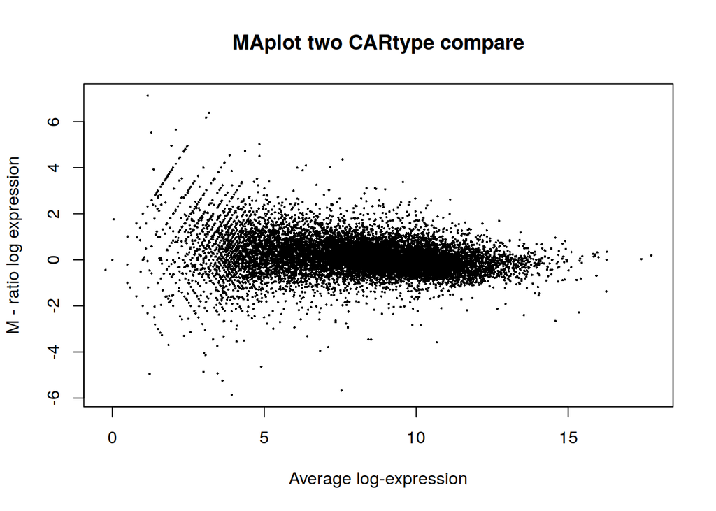

```r
plotMA(log2(filtered_data_matrix[,c(1,3)]), ylab="M - ratio log expression",
       main="MAplot two CARtype compare")
```

The above plot picked a sample from 4-1BB/CD3z group and a sample from CD28/CD3z group. The plot shows the mean log-expression of both samples are in normal range, and the M-ratio shows that quite many genes expressed differentially as not all points hugged in zero line. Some of the genes upregulated, some downrugulated.

The plot drawn from two samples is a quick peek at how many genes might involved in differential expression.

# 4. MDS plot

The above MAplot compare just two samples. The MDS plot can visualize sample data distances across whole groups.

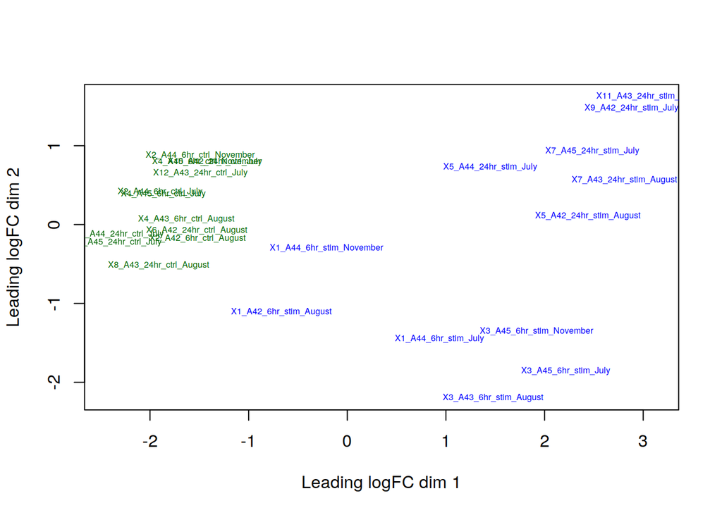

```r
plotMDS(d, labels=rownames(samples),
        col = c("darkgreen","blue")[factor(samples$stim_ctrl)], cex=0.5)
```

The above plot is based on stimulate-control group division, and groups are clearly cluster together in the plot, indicating clear difference between stimulate and control groups.

But the main idea of the experiment is: is there difference between different CAR types? So I plot according to CAR_type:

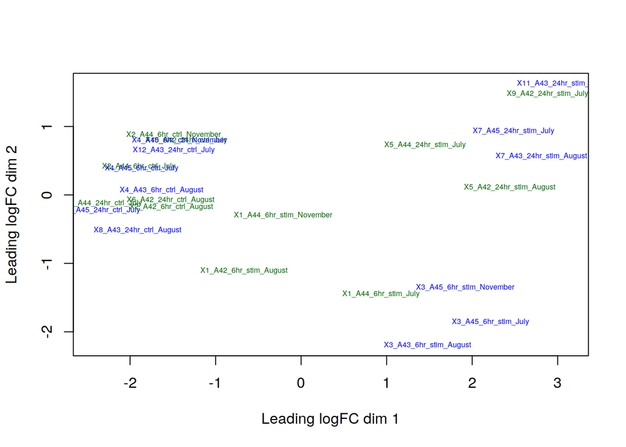

```r
plotMDS(d, labels=rownames(samples),
        col = c("darkgreen","blue")[factor(samples$CAR_type)], cex=0.5)
```

The plot is more subtle, needs further analysis. In section 5 I intended to find out how many genes are significantly differentially expressed induced by different CAR type.

The time points difference also apparent in the MDS plot.

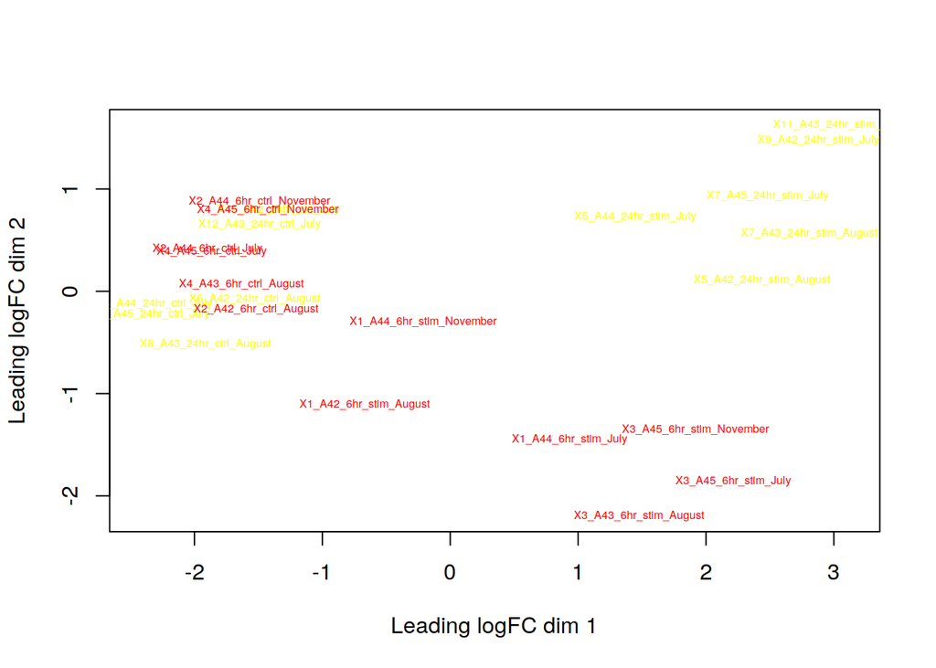

```r
plotMDS(d, labels=rownames(samples),
        col = c("yellow","red")[factor(samples$time_point)], cex=0.5)
```

# 5. Calculate P-Values and dispersion plot, mean-variance plot

## 5.1 P-values

For this analysis I chose the 0.05 significant threshold as this is the common standard. For multiple hypotheses testing used Benjamni-Hochberg threshold, also very common, less stringent than Bonferroni correction.

In first analysis model design is based on stimulate-control compare.

```r
minimalSet <- ExpressionSet(assayData=normalized_count_data)

model_design_stim <- model.matrix(
  ~ samples$stim_ctrl)

fit_stim <- lmFit(minimalSet, model_design_stim)
fit2_stim <- eBayes(fit_stim,trend=TRUE)
topfit_stim <- topTable(fit2_stim,
                       coef=ncol(model_design_stim),
                       adjust.method = "BH",
                       number = nrow(normalized_count_data))
output_hits_stim <- merge(normalized_count_data[,1],
                         topfit_stim,by.y=0,by.x=1,all.y=TRUE)
#sort by p-value
output_hits_stim <- output_hits_stim[order(output_hits_stim$P.Value),]
output_hits_stim[1:10,]
```

```
##                   x       logFC    AveExpr         t      P.Value    adj.P.Val
## 7465         NFKBIA  248.150793 171.300211  16.33966 1.506724e-14 2.163203e-10
## 10346 RP11-93B14.10   -3.454166   2.258039 -14.39810 2.423471e-13 1.692105e-09
## 13800       ZFP36L2 -478.084901 413.718673 -14.14924 3.535776e-13 1.692105e-09
## 12080          TBCC  -49.545661  56.678631 -13.49206 9.838500e-13 3.507575e-09
## 6226         LINGO3  -27.240516  18.587801 -13.35619 1.221556e-12 3.507575e-09
## 1947           CCM2 -137.736132 125.674035 -13.04607 2.014806e-12 4.821095e-09
## 2140         CDKN1B -138.027630 159.850293 -12.73131 3.379554e-12 6.931465e-09
## 10348  RP11-93B14.9  -22.796747  16.657749 -12.44058 5.496525e-12 9.355677e-09
## 8009         PBXIP1 -423.946304 292.432855 -12.40219 5.864811e-12 9.355677e-09
## 4132         FAM8A1  -78.787014  58.041709 -12.17958 8.567447e-12 1.051718e-08
##              B
## 7465  4.615113
## 10346 4.281305
## 13800 4.230520
## 12080 4.085879
## 6226  4.053930
## 1947  3.978174
## 2140  3.897043
## 10348 3.818056
## 8009  3.807322
## 4132  3.743632
```

```r
length(which(output_hits_stim$P.Value < 0.05))
```

```
## [1] 10105
```

```r
length(which(output_hits_stim$adj.P.Val < 0.05))
```

```
## [1] 9665
```

Thousands of rows P-values, not only passed 0.05 threshold, but also passed the multiple hypothesis standard Benjamni-Hochberg threshold. The result is clearly significant.

Then again we are interested in CAR type samples compare. I need model design based on combination of CAR_type and stim_ctrl.

```r
model_design_comb <- model.matrix(
  ~ samples$stim_ctrl + samples$CAR_type)
fit_comb <- lmFit(minimalSet, model_design_comb)
fit2_comb <- eBayes(fit_comb,trend=TRUE)
topfit_comb <- topTable(fit2_comb,
                        coef=ncol(model_design_comb),
                        adjust.method = "BH",
                        number = nrow(normalized_count_data))
output_hits_comb <- merge(normalized_count_data[,1],
                          topfit_comb,by.y=0,by.x=1,all.y=TRUE)

output_hits_comb <- output_hits_comb[order(output_hits_comb$P.Value),]
length(which(output_hits_comb$P.Value < 0.05))
```

```
## [1] 851
```

```r
length(which(output_hits_comb$adj.P.Val < 0.05))
```

```
## [1] 0
```

This time 851 genes passed 0.05 P-value threshold but none pass the Benjamni-Hochberg multiple hypothesis test standard. I tried (maybe more stringent) Benjamini-Yekutieli standard and the result was the same.

This means the expression difference of two CAR types sample are some what significant but failed to pass multiple hypothesis testing. My thinking is the BH or BY standard maybe too stringent to pass. The difference in expression can be seen clearly by the following heatmap in section 6.

If add time points factor, then the diffenrence is more signifcant.

```r
model_design_time <- model.matrix(~ samples$stim_ctrl
                                  + samples$CAR_type + samples$time_point)
fit_time <- lmFit(minimalSet, model_design_time)
fit2_time <- eBayes(fit_time,trend=TRUE)
topfit_time <- topTable(fit2_time,
                        coef=ncol(model_design_time),
                        adjust.method = "BH",
                        number = nrow(normalized_count_data))
output_hits_time <- merge(normalized_count_data[,1],
                          topfit_time,by.y=0,by.x=1,all.y=TRUE)

output_hits_time <- output_hits_time[order(output_hits_time$P.Value),]
length(which(output_hits_time$P.Value < 0.05))
```

```
## [1] 4713
```

```r
length(which(output_hits_time$adj.P.Val < 0.05))
```

```
## [1] 2131
```

This time also passed the Benjamni-Hochberg standard. Meaning the CAR type difference is significant if compounding diffenrent time points. For example, the paper mentioned early stage difference of expression induced by CD28/CD3z.

## 5.2 Dispersion plot and mean-variance plot

Based on above model I can draw a gene dispersion plot.

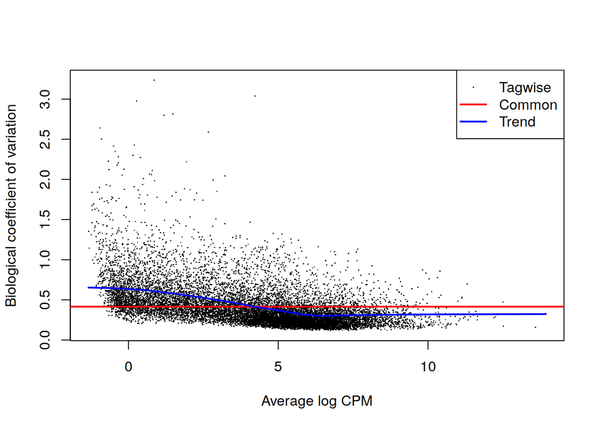

```r
d <- estimateDisp(d, model_design_comb)
plotBCV(d, col.tagwise = "black", col.common = "red")
```

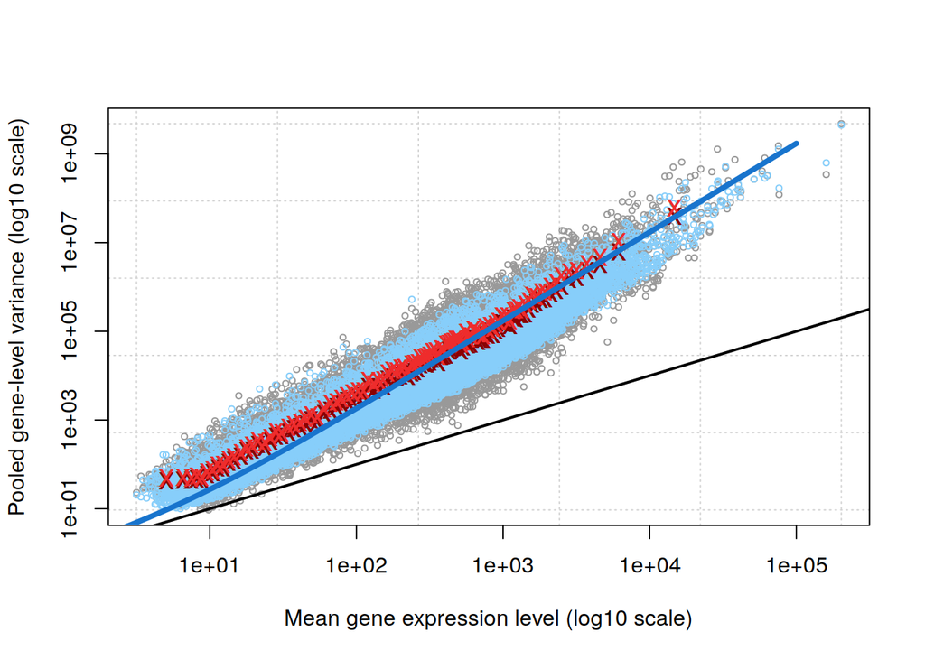

```r
plotMeanVar(d, show.raw.vars = TRUE, show.tagwise.vars=TRUE,
            show.ave.raw.vars = TRUE,
            NBline=TRUE,
            show.binned.common.disp.vars = TRUE)
```

The plot shows highly expressed genes tend to have high variance.

# 6. Heatmap

Heatmap for all data has too high computational load when perform distance calculation for cluster, actually we only interested in genes with significant p-values. Here I build a heatmap out of rows in tophits from combination of CAR_type and stim_ctrl model .

```r
library(ComplexHeatmap)
library(circlize)
heatmap_matrix <- normalized_count_data[,2:ncol(normalized_count_data)]
rownames(heatmap_matrix) <- rownames(normalized_count_data)
colnames(heatmap_matrix) <- colnames(normalized_count_data[,2:ncol(normalized_count_data)])

top_hits <- output_hits_comb$x[output_hits_comb$P.Value<0.05]
top_hits[1:10]
```

```
##  [1] "BEND4"    "ADAM22"   "ST8SIA1"  "SGK223"   "GALNT12"  "CLECL1"
##  [7] "MPZL3"    "COL6A1"   "SLC37A2"  "ARHGAP10"
```

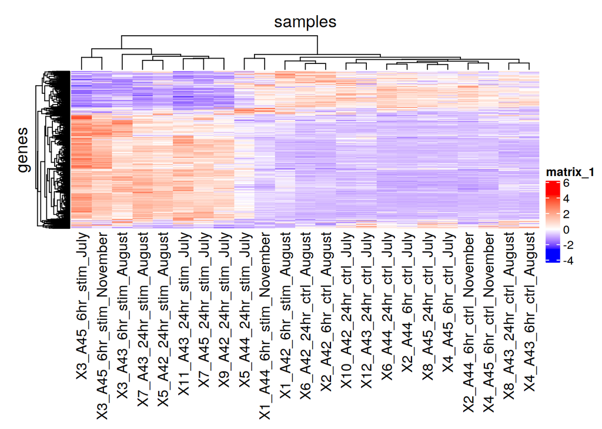

```r
heatmap_matrix_tophits <- t(
  scale(t(heatmap_matrix[
    which(rownames(heatmap_matrix) %in% top_hits),])))

if(min(heatmap_matrix_tophits) == 0){
  heatmap_col = colorRamp2(c( 0, max(heatmap_matrix_tophits)),
                           c( "white", "red"))
} else {
  heatmap_col = colorRamp2(c(min(heatmap_matrix_tophits), 0,
                             max(heatmap_matrix_tophits)), c("blue", "white", "red"))
}

current_heatmap <- Heatmap(as.matrix(heatmap_matrix_tophits),
                           cluster_rows = TRUE,
                           cluster_columns = TRUE,
                           show_row_dend = TRUE,
                           show_column_dend = TRUE,
                           col=heatmap_col,
                           show_column_names = TRUE,
                           show_row_names = FALSE,
                           show_heatmap_legend = TRUE,
                           row_title = "genes",
                           column_title = "samples"
)
current_heatmap
```

Also rows cluster together, indicating some groups of genes upregulated(red block) in stimulated group but the same genes downregulated(blue block) in control group, some genes downregulated in stimulated group but the same genes upregulated in control group.

I need another heatmap that contrast the two CAR types samples, this heatmap will not cluster on colums but put same CAR type columns together.

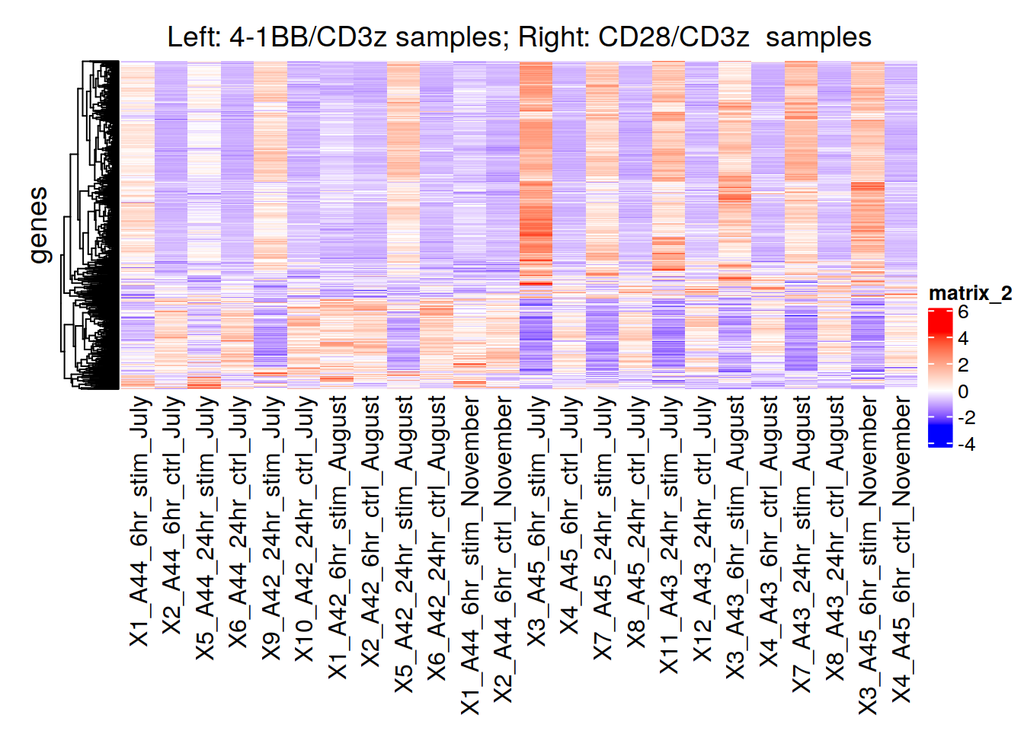

```r
heatmap_matrix <- cbind(normalized_count_data[,cartype1],normalized_count_data[,cartype2])

heatmap_matrix_tophits <- t(
  scale(t(heatmap_matrix[
    which(rownames(heatmap_matrix) %in% top_hits),])))

if(min(heatmap_matrix_tophits) == 0){
  heatmap_col = colorRamp2(c( 0, max(heatmap_matrix_tophits)),
                           c( "white", "red"))
} else {
  heatmap_col = colorRamp2(c(min(heatmap_matrix_tophits), 0,
                             max(heatmap_matrix_tophits)), c("blue", "white", "red"))
}

current_heatmap <- Heatmap(as.matrix(heatmap_matrix_tophits),
                           cluster_rows = TRUE,
                           cluster_columns = FALSE,
                           show_row_dend = TRUE,
                           show_column_dend = TRUE,
                           col=heatmap_col,
                           show_column_names = TRUE,
                           show_row_names = FALSE,
                           show_heatmap_legend = TRUE,
                           row_title = "genes",
                           column_title = "Left: 4-1BB/CD3z samples; Right: CD28/CD3z  samples"
)
current_heatmap
```

Patterns on this heatmap is more subtle. Although clearly columns contrast each other, indicating samples generally differ each other, with blue-lighter control samples interlased with red-darker simulated samples.

The 4-1BB/CD3z samples on the left generally blue-lighter, the right CD28/CD3z samples are generally red-darker, althought contrast is not too strong.

Meaning the CD28/CD3z samples induce relatively higher expression, this is consistant with the data summary of series GSE109161 that states “CD28/CD3z CAR stimulation initiated more marked early transcriptional changes with greater fold increases in the expression”.

Another way to group samples is according to time points. The below heatmap put all 12 control samples on the left, then the 12 stimulated samples devided in two groups: 6 hour and 24 hours.

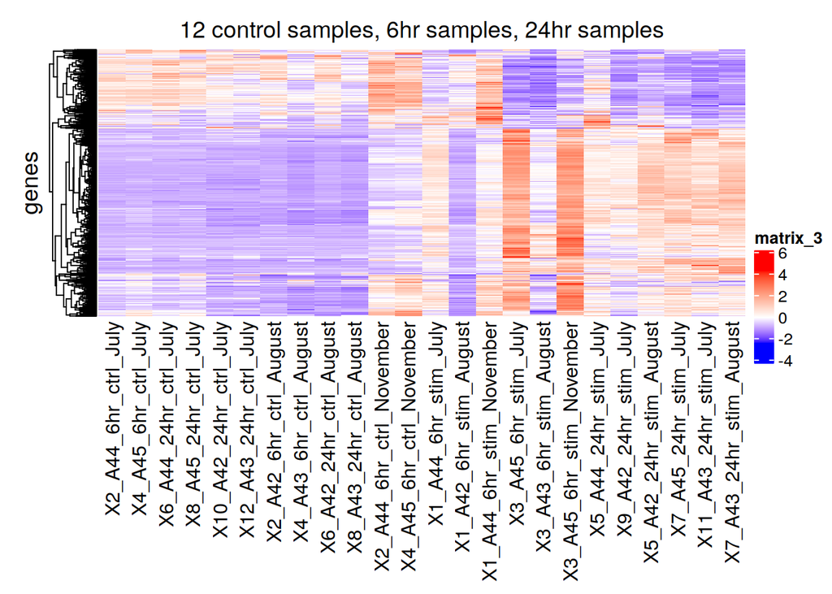

```r
ctrl_col <- rownames(samples[samples$stim_ctrl=="ctrl",])
ctrl_sample <- filtered_data_matrix[, ctrl_col]
type1_6hr <- rownames(samples[samples$time_point=="6hr" & samples$CAR_type =="4-1BB/CD3z"
                              & samples$stim_ctrl == "stim",])
type1_6hr_sample <- filtered_data_matrix[, type1_6hr]
type1_24hr <- rownames(samples[samples$time_point=="24hr" & samples$CAR_type =="4-1BB/CD3z"
                              & samples$stim_ctrl == "stim",])
type1_24hr_sample <- filtered_data_matrix[, type1_24hr]
type2_6hr <- rownames(samples[samples$time_point=="6hr" & samples$CAR_type =="CD28/CD3z"
                              & samples$stim_ctrl == "stim",])
type2_6hr_sample <- filtered_data_matrix[, type2_6hr]
type2_24hr <- rownames(samples[samples$time_point=="24hr" & samples$CAR_type =="CD28/CD3z"
                               & samples$stim_ctrl == "stim",])
type2_24hr_sample <- filtered_data_matrix[, type2_24hr]
heatmap_matrix <- cbind(ctrl_sample, type1_6hr_sample, type2_6hr_sample, type1_24hr_sample, type2_24hr_sample)

heatmap_matrix_tophits <- t(
  scale(t(heatmap_matrix[
    which(rownames(heatmap_matrix) %in% top_hits),])))

heatmap_matrix_tophits[is.na(heatmap_matrix_tophits)] <- 0
if(min(heatmap_matrix_tophits) == 0){
  heatmap_col = colorRamp2(c( 0, max(heatmap_matrix_tophits)),
                           c( "white", "red"))
} else {
  heatmap_col = colorRamp2(c(min(heatmap_matrix_tophits), 0,
                             max(heatmap_matrix_tophits)), c("blue", "white", "red"))
}

current_heatmap <- Heatmap(as.matrix(heatmap_matrix_tophits),
                           cluster_rows = TRUE,
                           cluster_columns = FALSE,
                           show_row_dend = TRUE,
                           show_column_dend = TRUE,
                           col=heatmap_col,
                           show_column_names = TRUE,
                           show_row_names = FALSE,
                           show_heatmap_legend = TRUE,
                           row_title = "genes",
                           column_title = "12 control samples, 6hr samples, 24hr samples"
)
current_heatmap
```

This heatmap reveals another aspect: regardless CAR type, 6 hours samples show similarty with 6 hours groups, as are 24hours groups. But different genes expressed in 6 hours group than that of 24 hours.

# 7. Thresholded over-representation analysis

The heatmap visually indicating groups of genes upregulated or downregulated, this section is to find out which of the genes over-representated and involved in which of the pathways or biological processes.

## 7.1 Find over-representated genes

```r
d = DGEList(counts=filtered_data_matrix, group=samples$CAR_type)
d <- estimateDisp(d, model_design_comb)
d <- calcNormFactors(d)
fit <- glmQLFit(d, model_design_comb)
qlf.cartype <- glmQLFTest(fit, coef='samples$CAR_typeCD28/CD3z')
qlf_output_hits <- topTags(qlf.cartype,sort.by = "PValue",
                           n = nrow(filtered_data_matrix))
length(which(qlf_output_hits$table$PValue < 0.05))
```

```
## [1] 874
```

```r
length(which(qlf_output_hits$table$FDR < 0.05))
```

```
## [1] 0
```

```r
topTags(qlf.cartype)
```

```
## Coefficient:  samples$CAR_typeCD28/CD3z
##                  logFC     logCPM        F       PValue       FDR
## BEND4       -0.9537745  1.5664672 28.55908 1.657809e-05 0.1202228
## IGF2         4.1453906  0.1439115 27.37252 2.204576e-05 0.1202228
## ST8SIA1     -2.5005554  1.7646365 26.83825 2.512143e-05 0.1202228
## ARHGAP10    -0.8458965  4.6492491 24.32142 4.741849e-05 0.1529173
## VCAM1       -2.3245066  3.6607103 23.74380 5.513240e-05 0.1529173
## MAF          1.5175322  4.2579100 23.18494 6.390636e-05 0.1529173
## SLC37A2      1.1831581  0.6906480 20.74732 1.244726e-04 0.2552933
## SPRY4        2.3214545 -0.7261165 19.99192 1.542525e-04 0.2768254
## MIR4435-2HG  1.0458134  3.8236969 19.55622 1.748840e-04 0.2789788
## IL10         3.7555961  2.4874232 19.18699 1.947212e-04 0.2794881
```

```r
length(which(qlf_output_hits$table$PValue < 0.05
             & qlf_output_hits$table$logFC > 0))
```

```
## [1] 414
```

```r
length(which(qlf_output_hits$table$PValue < 0.05
             & qlf_output_hits$table$logFC < 0))
```

```
## [1] 460
```

```r
qlf_output_hits_withgn <- merge(car_exp[,1],qlf_output_hits,
                                by.x=1, by.y = 0)
qlf_output_hits_withgn[,"rank"] <- -
  log(qlf_output_hits_withgn$PValue,base =10) *
  sign(qlf_output_hits_withgn$logFC)
qlf_output_hits_withgn <-
  qlf_output_hits_withgn[order(qlf_output_hits_withgn$rank),]
upregulated_genes <- qlf_output_hits_withgn$x[
  which(qlf_output_hits_withgn$PValue < 0.05
        & qlf_output_hits_withgn$logFC > 0)]

downregulated_genes <- qlf_output_hits_withgn$x[
  which(qlf_output_hits_withgn$PValue < 0.05
        & qlf_output_hits_withgn$logFC < 0)]

write.table(x=upregulated_genes,file=("./data/car_upregulated_genes.txt"),sep = "\t",
            row.names = FALSE,col.names = FALSE,quote = FALSE)

write.table(x=downregulated_genes,
            file=("./data/car_downregulated_genes.txt"),sep = "\t",
            row.names = FALSE,col.names = FALSE,quote = FALSE)
```

The above code shows number of upregulated and downregulated genes are on roughly the same scale. The result genes are separately stored in list files.

## 7.2 MA plot

Plot the above result in MA plot:

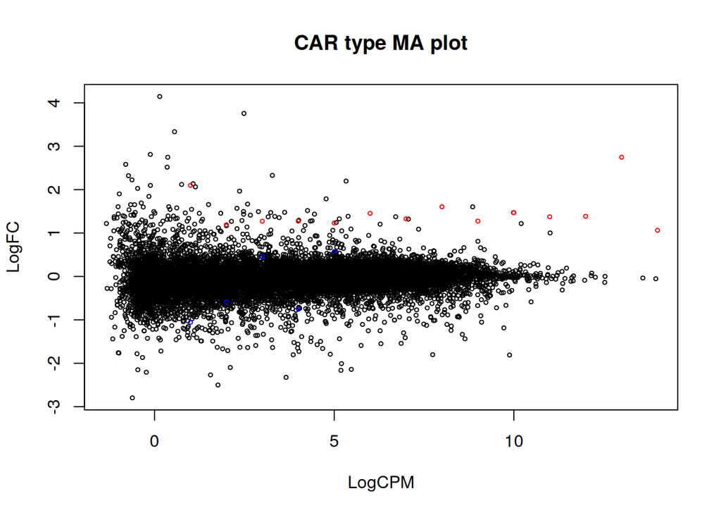

```r
up <- qlf.cartype[which(qlf.cartype$table$PValue < 0.05 & qlf.cartype$table$logFC > 1),]
down <- qlf.cartype[which(qlf.cartype$table$PValue < 0.05
                              & qlf_output_hits$table$logFC < -1),]

plot(qlf.cartype$table$logCPM, qlf.cartype$table$logFC, cex = .5, main = "CAR type MA plot", xlab = "LogCPM",ylab = "LogFC")
points(up$table$logFC, cex = .5, col = "red")
points(down$table$logFC, cex = .5, col = "blue")
```

## 7.3 Over-representation analysis using g:Profiler

I used g:Profiler for this report. Choose this tool because its friendly interfaces and I have already familiar with it. It data sources includes the most sources we are interested and the data are regularly updated and curated.

The process of inquiry:

*In g:Profiler web service, upload the gene list(upregulated and downregulated genes separately).

*In data sources option select the three sources GO:BP, Reactome, Wikipathway. Choose these annotations because I am seeking the biological processes or pathways the selected genes are involved, terms like cellular component and molecular function not relevant.

*In “Significance threshold” select “Benjamini-Hochberg FDR”

*Run query, some genes matched to multiple ensemble ID, use option: “select the Ensembl IDs with the most GO annotations”, rerun query.

### Upregulated genes results

Downloaded png for visualized upregulated genes result:

[figure not shown]

Screenshot for upregulated genes result:

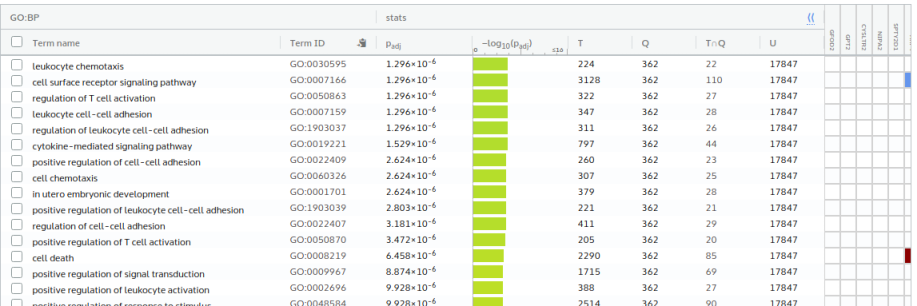

Table generated from downloaded csv file, top results for three data resources:

```r
upregulated_result = read.csv("./data/gProfiler_up.csv",header=TRUE,stringsAsFactors=FALSE)

library(knitr)
kable(upregulated_result[c(1:10,704:714,729:738),1:8], type="html")
```

|  | source | term_name | term_id | adjusted_p_value | negative_log10_of_adjusted_p_value | term_size | query_size | intersection_size |
| --- | --- | --- | --- | --- | --- | --- | --- | --- |
| 1 | GO:BP | leukocyte chemotaxis | GO:0030595 | 0.0000013 | 5.887535 | 224 | 362 | 22 |
| 2 | GO:BP | cell surface receptor signaling pathway | GO:0007166 | 0.0000013 | 5.887535 | 3128 | 362 | 110 |
| 3 | GO:BP | regulation of T cell activation | GO:0050863 | 0.0000013 | 5.887535 | 322 | 362 | 27 |
| 4 | GO:BP | leukocyte cell-cell adhesion | GO:0007159 | 0.0000013 | 5.887535 | 347 | 362 | 28 |
| 5 | GO:BP | regulation of leukocyte cell-cell adhesion | GO:1903037 | 0.0000013 | 5.887535 | 311 | 362 | 26 |
| 6 | GO:BP | cytokine-mediated signaling pathway | GO:0019221 | 0.0000015 | 5.815457 | 797 | 362 | 44 |
| 7 | GO:BP | positive regulation of cell-cell adhesion | GO:0022409 | 0.0000026 | 5.580974 | 260 | 362 | 23 |
| 8 | GO:BP | cell chemotaxis | GO:0060326 | 0.0000026 | 5.580974 | 307 | 362 | 25 |
| 9 | GO:BP | in utero embryonic development | GO:0001701 | 0.0000026 | 5.580974 | 379 | 362 | 28 |
| 10 | GO:BP | positive regulation of leukocyte cell-cell adhesion | GO:1903039 | 0.0000028 | 5.552430 | 221 | 362 | 21 |
| 704 | REAC | Interleukin-10 signaling | REAC:R-HSA-6783783 | 0.0000000 | 8.060253 | 45 | 236 | 13 |
| 705 | REAC | Signaling by Interleukins | REAC:R-HSA-449147 | 0.0000092 | 5.034679 | 617 | 236 | 37 |
| 706 | REAC | RUNX1 and FOXP3 control the development of regulatory T lymphocytes (Tregs) | REAC:R-HSA-8877330 | 0.0000092 | 5.034679 | 10 | 236 | 6 |
| 707 | REAC | Cytokine Signaling in Immune system | REAC:R-HSA-1280215 | 0.0000339 | 4.470146 | 832 | 236 | 43 |
| 708 | REAC | RUNX1 regulates transcription of genes involved in differentiation of myeloid cells | REAC:R-HSA-8939246 | 0.0006371 | 3.195825 | 6 | 236 | 4 |
| 709 | REAC | RUNX2 regulates genes involved in differentiation of myeloid cells | REAC:R-HSA-8941333 | 0.0016622 | 2.779313 | 3 | 236 | 3 |
| 710 | REAC | Signaling by MET | REAC:R-HSA-6806834 | 0.0066204 | 2.179117 | 77 | 236 | 9 |
| 711 | REAC | Interleukin-3, Interleukin-5 and GM-CSF signaling | REAC:R-HSA-512988 | 0.0084428 | 2.073512 | 47 | 236 | 7 |
| 712 | REAC | RUNX1 regulates transcription of genes involved in interleukin signaling | REAC:R-HSA-8939247 | 0.0095000 | 2.022278 | 5 | 236 | 3 |
| 713 | REAC | Immune System | REAC:R-HSA-168256 | 0.0095000 | 2.022278 | 2146 | 236 | 72 |
| 714 | REAC | Regulation of IFNG signaling | REAC:R-HSA-877312 | 0.0095000 | 2.022278 | 12 | 236 | 4 |
| 729 | WP | Cytokines and Inflammatory Response | WP:WP530 | 0.0000631 | 4.199797 | 26 | 173 | 8 |
| 730 | WP | Lung fibrosis | WP:WP3624 | 0.0000631 | 4.199797 | 63 | 173 | 11 |
| 731 | WP | Allograft Rejection | WP:WP2328 | 0.0002256 | 3.646680 | 88 | 173 | 12 |
| 732 | WP | T-Cell antigen Receptor (TCR) pathway during Staphylococcus aureus infection | WP:WP3863 | 0.0002646 | 3.577390 | 62 | 173 | 10 |
| 733 | WP | miRNAs involvement in the immune response in sepsis | WP:WP4329 | 0.0065223 | 2.185597 | 58 | 173 | 8 |
| 734 | WP | VEGFA-VEGFR2 Signaling Pathway | WP:WP3888 | 0.0069235 | 2.159675 | 236 | 173 | 17 |
| 735 | WP | Control of immune tolerance by vasoactive intestinal peptide | WP:WP4484 | 0.0095010 | 2.022233 | 13 | 173 | 4 |
| 736 | WP | Photodynamic therapy-induced NF-kB survival signaling | WP:WP3617 | 0.0095010 | 2.022233 | 35 | 173 | 6 |
| 737 | WP | Hematopoietic Stem Cell Differentiation | WP:WP2849 | 0.0248770 | 1.604203 | 61 | 173 | 7 |
| 738 | WP | Spinal Cord Injury | WP:WP2431 | 0.0248770 | 1.604203 | 117 | 173 | 10 |

### Downregulated genes results

Downloaded png for visualized downregulated genes result:

[figure not shown]

Screenshot for downregulated genes result:

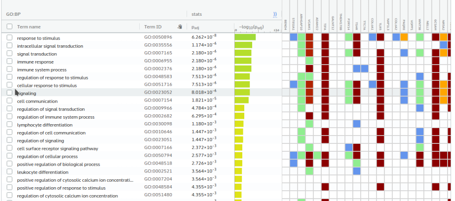

Table generated from downloaded csv file, top results for three data resources:

```r
downregulated_result = read.csv("./data/gProfiler_down.csv",header=TRUE,stringsAsFactors=FALSE)

library(knitr)
kable(downregulated_result[c(1:10,85:87),1:8], type="html")
```

|  | source | term_name | term_id | adjusted_p_value | negative_log10_of_adjusted_p_value | term_size | query_size | intersection_size |
| --- | --- | --- | --- | --- | --- | --- | --- | --- |
| 1 | GO:BP | response to stimulus | GO:0050896 | 0.0000001 | 7.203263 | 9379 | 327 | 231 |
| 2 | GO:BP | intracellular signal transduction | GO:0035556 | 0.0000012 | 5.930327 | 2880 | 327 | 97 |
| 3 | GO:BP | signal transduction | GO:0007165 | 0.0000022 | 5.661500 | 6210 | 327 | 166 |
| 4 | GO:BP | immune response | GO:0006955 | 0.0000022 | 5.661500 | 2286 | 327 | 81 |
| 5 | GO:BP | immune system process | GO:0002376 | 0.0000022 | 5.661500 | 3214 | 327 | 103 |
| 6 | GO:BP | regulation of response to stimulus | GO:0048583 | 0.0000075 | 5.124173 | 4370 | 327 | 126 |
| 7 | GO:BP | cellular response to stimulus | GO:0051716 | 0.0000075 | 5.124173 | 7670 | 327 | 191 |
| 8 | GO:BP | signaling | GO:0023052 | 0.0000080 | 5.095914 | 6681 | 327 | 172 |
| 9 | GO:BP | cell communication | GO:0007154 | 0.0000182 | 4.739610 | 6706 | 327 | 171 |
| 10 | GO:BP | regulation of signal transduction | GO:0009966 | 0.0004784 | 3.320250 | 3209 | 327 | 94 |
| 85 | REAC | Butyrophilin (BTN) family interactions | REAC:R-HSA-8851680 | 0.0228125 | 1.641828 | 12 | 203 | 4 |
| 86 | REAC | Immune System | REAC:R-HSA-168256 | 0.0228125 | 1.641828 | 2146 | 203 | 65 |
| 87 | WP | DNA Damage Response (only ATM dependent) | WP:WP710 | 0.0055985 | 2.251929 | 110 | 139 | 11 |

# 8. Interpretation

**1. Stimulated vs control(rest cell) samples comparison**

The two groups expression difference is significant and obvious seen from P-values and heatmap.

**2. Two CAR type 4-1BB/CD3z vs CD28/CD3z samples comparison**

From P-value calculation, heatmap, MDS plot, the difference of expression of two CAR type samples, is not very clear. But the T-test for the two groups data is significant.

P-values calculation in section 5 of two CAR type compare result in 851 genes pass the 0.05 threshold but none pass Benjamni-Hochberg standard. But if taking into account time points, thousands of genes p-values are significant even after multiple hypothesis test.

The second heatmap in section 6, indicating CD28/CD3z samples induce more expression of some genes, consistant with the original paper.

**3. The top enrichment analysis results, are the results expected?**

By the description of the paper, chimeric antigen receptor modify T cells to recognize cancer cells in order to attack tumour. In the process CAR linking an antigen recognition domain to T cell signalling modules comprised of CD3z to provide signal, and CD28 or 4-1BB to provide costimulation. Looking from this perspective, the top list of pathways related to upregulated genes are all related to the CAR function:

leukocyte chemotaxis, cell surface receptor signaling pathway, regulation of T cell activation, leukocyte cell-cell adhesion, regulation of leukocyte cell-cell adhesion, T-Cell antigen Receptor (TCR) pathway during Staphylococcus aureus infection.

So the results for upregulated genes are highly expected.

For the downregulated genes, the top pathway list include:

Response to stimulus, intracellular signal transduction, signal transduction, immune response, immune system process,etc.

These are roughly related to stimulation in immune cells, but maybe not specifically expected or designed for CAR production. It’s possible they are related to side effect or toxicity of the CAR treatment, and seeking these over-representation results is one purpose of this experiment.

**4. Do the over-representation results support conclusions or mechanism discussed in the original paper?**

In this assignment I focused on what can be directly showed from the data, and whole groups comparison, the paper was seeking more detailed comparison of specific genes in order to find genes related to efficacy and toxicity of CAR treatment.

The results of this assignment support the conclusion of the original paper in general, as I see the over-representated genes involve processes or pathways related to the effect of CAR treatment, but the paper has more detailed study of specific genes.

**5. Other publications that support some of my results**

CAR ligation modified T cells described in another paper (Henderson et al. 2013), the CAR ligation produced the cytokines IFN-γ, IL-2, IL-4, IL-10, TNF-α and IL-17.

In my analysis I found the similar results, the report in the above paper surport my finding. For example IL2 was among upregulated gene list, and the result is significant:

```r
qlf_output_hits_withgn[qlf_output_hits_withgn$x=="IL2",]
```

```
##        x    logFC   logCPM        F      PValue       FDR     rank
## 5424 IL2 1.472362 3.232688 7.832573 0.009872232 0.7334858 2.005585
```

```r
qlf_output_hits_withgn[qlf_output_hits_withgn$x=="IL4",]
```

```
##        x     logFC   logCPM        F     PValue       FDR     rank
## 5441 IL4 0.9729763 1.658989 3.352031 0.07936862 0.7334858 1.100351
```

```r
qlf_output_hits_withgn[qlf_output_hits_withgn$x=="IL10",]
```

```
##         x    logFC   logCPM        F       PValue       FDR     rank
## 5399 IL10 3.755596 2.487423 19.18699 0.0001947212 0.2794881 3.710587
```

```r
qlf_output_hits_withgn[qlf_output_hits_withgn$x=="TNF",]
```

```
##         x     logFC   logCPM        F     PValue       FDR     rank
## 12552 TNF 0.6878777 6.115726 5.854788 0.02334111 0.7334858 1.631879
```

Another paper (Cheadle et al. 2012) also had the same finding about IL2.

# References

Cheadle, EJ, DG Rothwell, JS Bridgeman, VE Sheard, RE Hawkins, and DE Gilham. 2012. “Ligation of the Cd2 Co-Stimulatory Receptor Enhances Il-2 Production from First-Generation Chimeric Antigen Receptor T Cells.” *Gene Therapy* 19 (11). Nature Publishing Group: 1114–20.

Henderson, Melissa A, Carmen SM Yong, Connie PM Duong, Alexander J Davenport, Liza B John, Christel Devaud, Paul Neeson, Jennifer A Westwood, Phillip K Darcy, and Michael H Kershaw. 2013. “Chimeric Antigen Receptor-Redirected T Cells Display Multifunctional Capacity and Enhanced Tumor-Specific Cytokine Secretion Upon Secondary Ligation of Chimeric Receptor.” *Immunotherapy* 5 (6). Future Medicine: 577–90.

Salter, Alexander I, Richard G Ivey, Jacob J Kennedy, Valentin Voillet, Anusha Rajan, Eva J Alderman, Uliana J Voytovich, et al. 2018. “Phosphoproteomic Analysis of Chimeric Antigen Receptor Signaling Reveals Kinetic and Quantitative Differences That Affect Cell Function.” *Science Signaling* 11 (544). American Association for the Advancement of Science: eaat6753.